# Problem Set 4

Author

Owen Brooks

Published

November 19, 2026

**GitHub repo:** https://github.com/owengbrooks/ec422_ps4_owenbrooks

```r
library(tidyverse)
library(fpp3)
library(BVAR)
```

## 2.1b

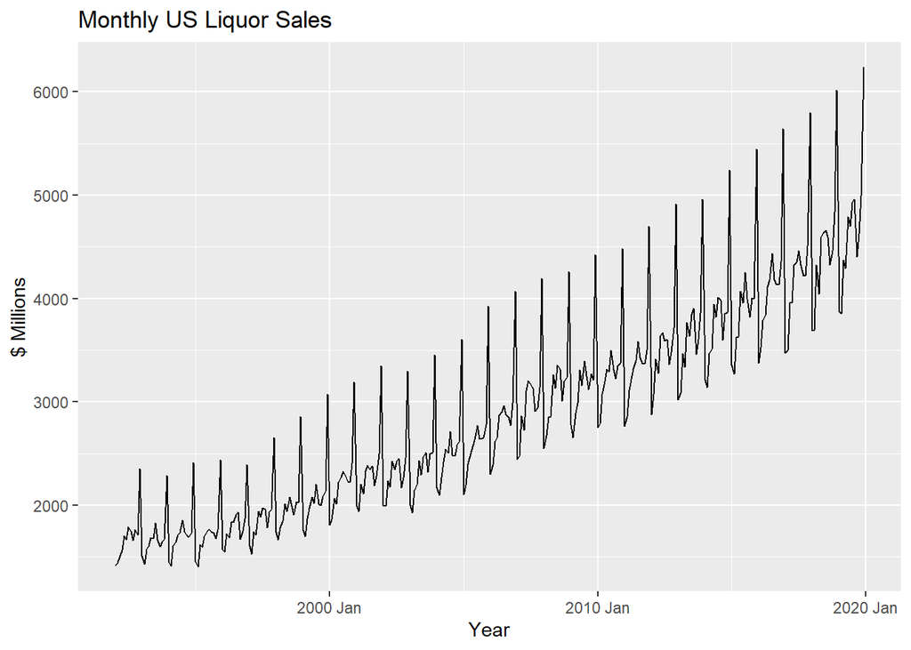

```r
liquor_raw <- read_csv(
  "data/MRTSSM4453USN.csv",
  na = ".",
  col_types = cols(
    observation_date = col_date(format = "%Y-%m-%d"),
    MRTSSM4453USN = col_double()
  )
)


liquor <- liquor_raw |>
  transmute(Month = yearmonth(observation_date), sales = MRTSSM4453USN) |>
  as_tsibble(index = Month) |>
  filter(Month <= yearmonth("2019 Dec"))


autoplot(liquor, sales) +
  labs(
    title = "Monthly US Liquor Sales",
    y = "$ Millions",
    x = "Year"
  )
```

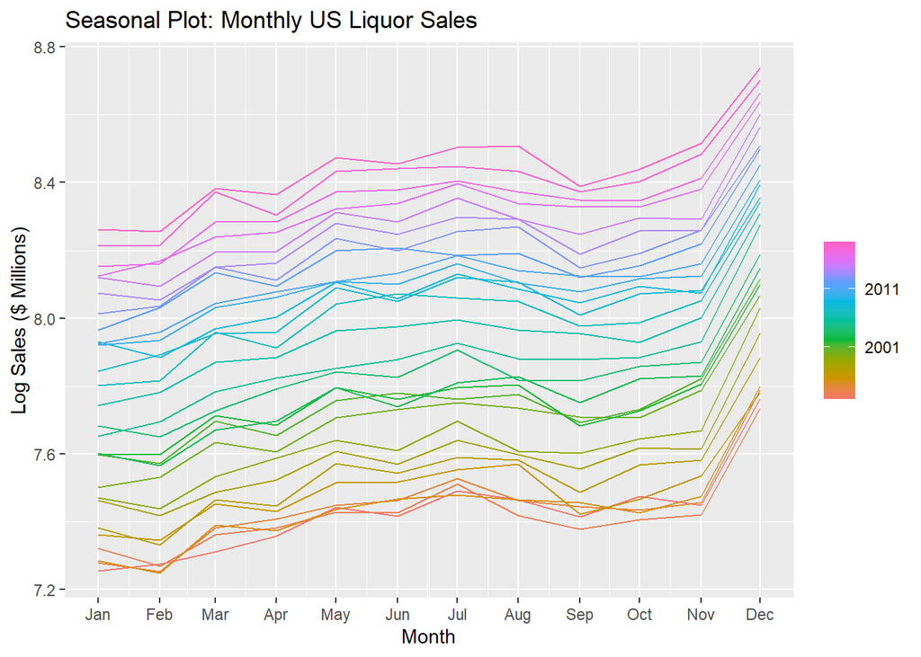

```r
liquor |>
  gg_season(log(sales)) +
  labs(title = "Seasonal Plot: Monthly US Liquor Sales",
       y = "Log Sales ($ Millions)",
       x = "Month")
```

It appears that liquor sales increase in the summer (which makes sense) and then spikes during the holiday season. Overall, the seasons and variation of liquor sales grows over time which suggests that logs are needed.

## 2.2a

For ARIMA one lag of dependent, two lags of error, a seasonal difference with two seasonal lags and one error lag was chosen. For ETS it says forecast errors enter additively, that it has an additive undamped trend, and that the seasonal pattern is additive.

```r
liquor_fit <- liquor |>
  model(arima = ARIMA(log(sales)),
        ets   = ETS(log(sales)))

liquor_fit |> select(arima) |> report()
```

```
Series: sales
Model: ARIMA(1,0,2)(2,1,1)[12] w/ drift
Transformation: log(sales)

Coefficients:
         ar1      ma1     ma2    sar1     sar2     sma1  constant
      0.8948  -0.7374  0.2477  0.3679  -0.2334  -0.8845    0.0036
s.e.  0.0355   0.0697  0.0623  0.0668   0.0665   0.0468    0.0001

sigma^2 estimated as 0.0005469:  log likelihood=752.43
AIC=-1488.85   AICc=-1488.4   BIC=-1458.61
```

```r
liquor_fit |> select(ets) |> report()
```

```
Series: sales
Model: ETS(A,A,A)
Transformation: log(sales)
  Smoothing parameters:
    alpha = 0.3296099
    beta  = 0.007560263
    gamma = 0.0001765132

  Initial states:
     l[0]         b[0]      s[0]      s[-1]        s[-2]       s[-3]      s[-4]
 7.412219 0.0007608238 0.3263441 0.03153301 -0.004849389 -0.03530501 0.02512163
      s[-5]      s[-6]      s[-7]       s[-8]      s[-9]     s[-10]     s[-11]
 0.05558624 0.01219515 0.02503206 -0.06088935 -0.0607952 -0.1578065 -0.1561667

  sigma^2:  7e-04

      AIC      AICc       BIC
-489.1517 -487.2272 -424.2608
```

## 2.2b

We can reject the the ljung box test and say that the residuals are not white noise.

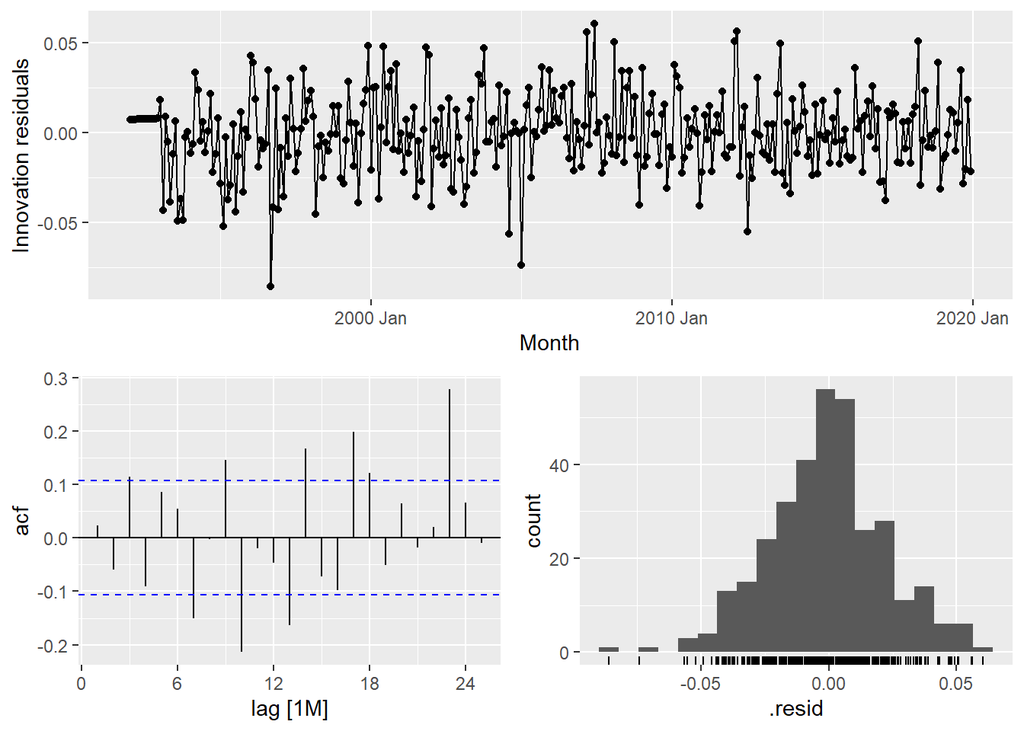

```r
liquor_fit |> select(arima) |> gg_tsresiduals()
```

```r
lb <- liquor_fit |>
  select(arima) |>
  augment() |>
  features(.innov, ljung_box, lag = 24, dof = 6)
lb
```

```
# A tibble: 1 × 3
  .model lb_stat lb_pvalue
  <chr>    <dbl>     <dbl>
1 arima     120.         0
```

## 2.3a

There will be 216 forecast origins (336 months - 120 window = 216).

## 2.3b

The first forecast is Jan 2002 and last is Dec 2019. Across the board, the ARIMA model forecasts more accurately in both RMSE and MAE.

```r
liquor_cv_fit <- readRDS("results/liquor_cv_fit.rds")

liquor_cv_fc <- liquor_cv_fit |>
  forecast(h = 1)
liquor_cv_fc |>
  accuracy(liquor, measures = list(RMSE = RMSE, MAE = MAE)) |> knitr::kable(digits = 2)
```

| .model | .type | RMSE | MAE |
| --- | --- | --- | --- |
| arima | Test | 81.62 | 65.84 |
| ets | Test | 94.35 | 72.31 |
| snaive | Test | 161.26 | 136.63 |

```r
liquor_errs <- liquor_cv_fc |>
  as_tibble() |>
  left_join(as_tibble(liquor) |> select(Month, actual = sales), by = "Month") |>
  mutate(e = actual - .mean) |>
  select(Month, .model, e) |>
  pivot_wider(names_from = .model, values_from = e)

forecast::dm.test(liquor_errs$arima, liquor_errs$ets, h = 1, power = 2)
```

```
    Diebold-Mariano Test

data:  liquor_errs$arimaliquor_errs$ets
DM = -2.8635, Forecast horizon = 1, Loss function power = 2, p-value =
0.004604
alternative hypothesis: two.sided
```

```r
forecast::dm.test(liquor_errs$arima, liquor_errs$snaive, h = 1, power = 2)
```

```
    Diebold-Mariano Test

data:  liquor_errs$arimaliquor_errs$snaive
DM = -10.724, Forecast horizon = 1, Loss function power = 2, p-value <
2.2e-16
alternative hypothesis: two.sided
```

## 2.4

The horse race between ARIMA and ETS has DM stat of -2.8635 and a p-value of 0.004604 and hence we conclude that ARIMA is significantly better than ETS. Between ARIMA and SNAIVE the DM stat is -10.72 and p-value is 2.2e-16 and so we conclude that ARIMA wins this horse race as well. I’d use ARIMA.

## 3

```r
liquor_combo_fc <- liquor_cv_fit |>
  mutate(combo = (arima + ets) / 2) |>
  forecast(h=1)

liquor_combo_fc |>
  accuracy(liquor, measures = list(RMSE = RMSE, MAE = MAE)) |> knitr::kable(digits = 2)
```

| .model | .type | RMSE | MAE |
| --- | --- | --- | --- |
| arima | Test | 81.62 | 65.84 |
| combo | Test | 85.28 | 66.86 |
| ets | Test | 94.35 | 72.31 |
| snaive | Test | 161.26 | 136.63 |

Combo lands in between ETS and ARIMA, which makes sense since its just a combination of the two.

## 3b

```r
cor(liquor_errs$arima, liquor_errs$ets)
```

```
[1] 0.8781934
```

The errors are positively correlated meaning that there wont’ be much gain in combining the models. They are estimating something similar and doing it in a similar way and with a DM showing ARIMA just does it better, combining them only adds noise.

## 4.1c

120 forecasts per variable first for 1990 Q1 and last for 2019 Q4.

## 4.2

```r
qd_raw <-  read_csv("data/fredqd_2026-09.csv", show_col_types = FALSE) |>
  slice(-(1:2))



growth <- function(x) 100 * difference(log(x))

qd <- qd_raw |>
  mutate(date = as.Date(sasdate, "%m/%d/%Y")) |>
  transmute(date,
            gdp    = growth(GDPC1),     # real GDP
            cons   = growth(PCECC96),   # real consumption
            inv    = growth(GPDIC1),    # real investment
            emp    = growth(PAYEMS),    # payroll employment
            infl   = growth(GDPCTPI),   # GDP price index
            unrate = difference(UNRATE),     # unemployment rate
            ffr    = difference(FEDFUNDS),   # federal funds rate
            gs10   = difference(GS10)) |>    # 10-year Treasury yield
  filter(date >= as.Date("1960-03-01"), date <= as.Date("2019-12-01"))

y <- qd |> select(-date) |> as.matrix()

nrow(y)
```

```
[1] 240
```

```r
head(y)
```

```
            gdp        cons         inv        emp      infl  unrate     ffr
[1,]  2.2237184  0.95210372   9.5789412  1.2792747 0.1884647 -0.4667 -0.0567
[2,] -0.5398116  1.25352433  -9.7837838  0.2416811 0.3564604  0.1000 -0.2366
[3,]  0.4887350 -0.40052924  -0.2544693 -0.5091283 0.4325238  0.3000 -0.7600
[4,] -1.2914344  0.12942668 -11.7409889 -0.5914079 0.4370749  0.7334 -0.6400
[5,]  0.6727499 -0.03714266   2.5619282 -0.5862248 0.1153772  0.5333 -0.2934
[6,]  1.6836022  1.47721924   6.7723497  0.3046958 0.1983937  0.2000 -0.2700
        gs10
[1,] -0.0966
[2,] -0.2267
[3,] -0.4267
[4,]  0.0534
[5,] -0.1000
[6,]  0.0033
```

```r
N <- nrow(y)
origins <- 120:(N -1)
actual <- y[121:N, ]


var_ols_fc <- function(z, p) {
  e <- embed(z, p + 1)            # columns: y_t, then its lags 1 to p
  M <- ncol(z)                    # number of variables
  B <- coef(lm(e[, 1:M] ~ e[, -(1:M)]))
  x <- c(1, t(z[nrow(z):(nrow(z) - p + 1), ]))   # constant, latest p lags
  x %*% B
}

fc_var1 <- NULL
fc_var4 <- NULL
for (T in origins) {
  fc_var1 <- rbind(fc_var1, var_ols_fc(y[1:T, ], 1))
  fc_var4 <- rbind(fc_var4, var_ols_fc(y[1:T, ], 4))
}


rmse_by_var <- function(f) sqrt(colMeans((actual - f)^2))

rmse_by_var(fc_var1)
```

```
      gdp      cons       inv       emp      infl    unrate       ffr      gs10
0.5130384 0.4598547 2.4927057 0.1956584 0.2084055 0.1988068 0.3902989 0.3610310
```

```r
rmse_by_var(fc_var4)
```

```
      gdp      cons       inv       emp      infl    unrate       ffr      gs10
0.5693241 0.5268484 2.5212629 0.2277561 0.2069608 0.2153966 0.4973504 0.3789663
```

## 4.3b

```r
var_results <- readRDS("results/var_results.rds")
var_results |> knitr::kable(digits = 3)
```

| Variable | VAR(1) | VAR(4) | BVAR(4), lambda = 0.3 | BVAR(4), lambda = 0.05 |
| --- | --- | --- | --- | --- |
| gdp | 0.513 | 0.569 | 0.539 | 0.567 |
| cons | 0.460 | 0.527 | 0.486 | 0.495 |
| inv | 2.493 | 2.521 | 2.385 | 2.698 |
| emp | 0.196 | 0.228 | 0.211 | 0.315 |
| infl | 0.208 | 0.207 | 0.197 | 0.330 |
| unrate | 0.199 | 0.215 | 0.203 | 0.216 |
| ffr | 0.390 | 0.497 | 0.414 | 0.358 |
| gs10 | 0.361 | 0.379 | 0.359 | 0.362 |

The BVAR(4) with lambda=0.3 beats the OLS VAR(4) on every variable. The reason is that it shrinks the lags biasing the coefficients a little bit but in turn significantly decreases the variance. Compared to VAR(1), VAR(1) wins on some while loses on others which makes sense in part since both deal with decreasing the SE but one does it through shrinkage the other just cutting. At lambda=0.05 I think the model overshrinks and gets rid of information biasing the estimate more than it helps. It is not a fair estimate since we picked the winner on the same evaluation sample so its RMSE is biased.

## 4.3c

```r
fc_bvar_03 <- readRDS("results/fc_bvar_03.rds")
e_var4 <- actual[, "gdp"] - fc_var4[, 1]
e_bvar <- actual[, "gdp"] - fc_bvar_03[, 1]

forecast::dm.test(e_var4, e_bvar, h = 1, power = 2)
```

```
    Diebold-Mariano Test

data:  e_var4e_bvar
DM = 2.1366, Forecast horizon = 1, Loss function power = 2, p-value =
0.03468
alternative hypothesis: two.sided
```

```r
e_var4_ffr <- actual[, "ffr"] - fc_var4[, 7]
e_bvar_ffr <- actual[, "ffr"] - fc_bvar_03[, 7]
forecast::dm.test(e_var4_ffr, e_bvar_ffr, h = 1, power = 2)
```

```
    Diebold-Mariano Test

data:  e_var4_ffre_bvar_ffr
DM = 1.9999, Forecast horizon = 1, Loss function power = 2, p-value =
0.04779
alternative hypothesis: two.sided
```

Both DM stats are positive, so the BVAR(4) lambda = 0.3 is the better model . The FFR that has the largest RMSE is only barely significant suggesting that the small gaps in 4.3b shouldn’t really be seen as meaningful.

## 5.1c

```r
tcode[c("INDPRO", "PAYEMS", "cpiaucsl", "FEDFUNDS")]
```

```
  INDPRO   PAYEMS     <NA> FEDFUNDS
       5        5       NA        2
```

Because the FEDFUNDS is already in percentage terms and in some sense is already transformed once, but INDPRO is not transformed prior and so needs more transformations to remove non-stationary and trends.

## 5.2a

```r
Z <- fm |> select(-date) |> as.matrix()

pc <- prcomp(scale(Z))

summary(pc)$importance[, 1:5]
```

```
                            PC1      PC2      PC3      PC4      PC5
Standard deviation     4.258002 2.993839 2.923106 2.597224 2.295261
Proportion of Variance 0.149840 0.074070 0.070620 0.055750 0.043540
Cumulative Proportion  0.149840 0.223910 0.294530 0.350280 0.393820
```

29% of the variation in all the series seen in cumulative proportion

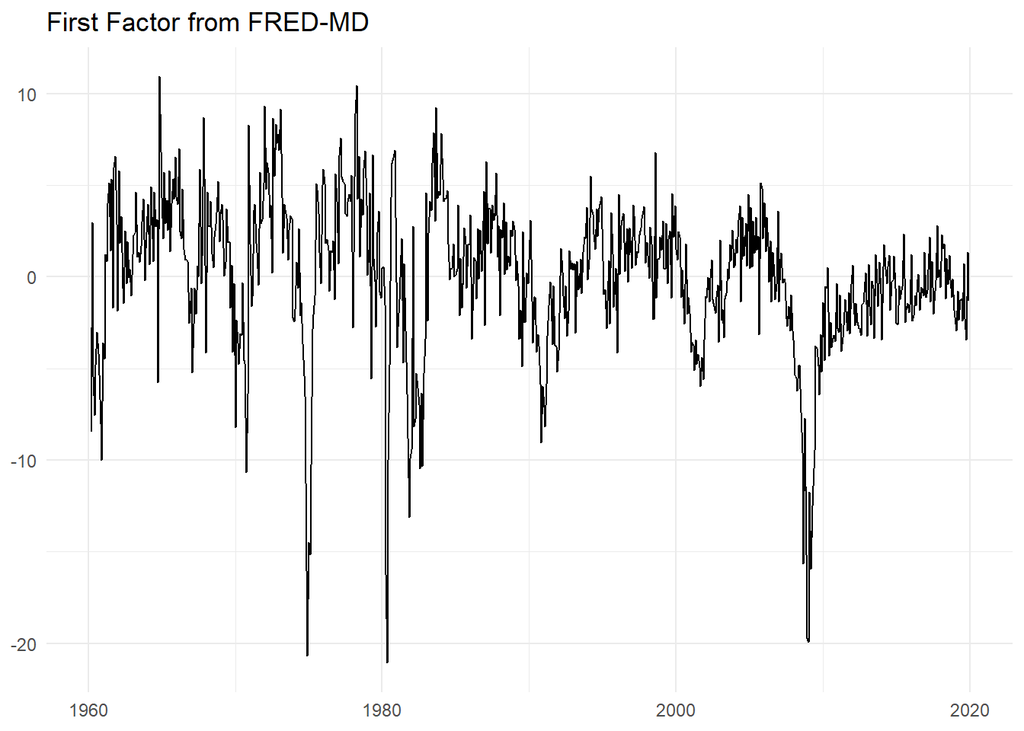

```r
F1 <- pc$x[, 1] * sign(cor(pc$x[, 1], fm$INDPRO))

tibble(date = fm$date, F1 = F1) |>
  ggplot(aes(date, F1)) +
  geom_line() +
  labs(title = "First Factor from FRED-MD", x = NULL, y = NULL) +
  theme_minimal()
```

## 5.2c

```r
sort(abs(cor(pc$x[, 1], Z))[1, ], decreasing = TRUE)[1:8]
```

```
   PAYEMS IPMANSICS    USGOOD    INDPRO    MANEMP   IPFPNSS    CUMFNS   DMANEMP
0.8415788 0.8404473 0.8390159 0.8219976 0.8028499 0.7903078 0.7778686 0.7768615
```

```r
sort(abs(cor(pc$x[, 2], Z))[1, ], decreasing = TRUE)[1:8]
```

```
    CUSR0000SAC DNDGRG3M086SBEA   CUSR0000SA0L2        CPIAUCSL   CUSR0000SA0L5
      0.7468587       0.7391330       0.7279202       0.7198020       0.7020307
       CPITRNSL           PCEPI        CPIULFSL
      0.6806883       0.6795890       0.6570361
```

According to the appendix names, the first factor is showing employment, industrial production, and manufacturing stuff and functionally is capturing real economic activity in the real economy. The plot shows how this responds to recessions (goes down). The second factor is loading on price indexes of goods and commodities and transportation so its capturing the inflation shocks.

## 5.3

```r
ip <- fm$INDPRO
n <- nrow(Z)
init <- which(fm$date == as.Date("1989-12-01"))

e_ar <- NULL
e_fa <- NULL
for (T in init:(n - 1)) {
  F_T <- prcomp(scale(Z[1:T, ]))$x[, 1:3]         # factors using data through T
  d <- data.frame(y_next = ip[2:T], y = ip[1:(T - 1)], F_T[1:(T - 1), ])
  new <- data.frame(y = ip[T], t(F_T[T, ]))
  e_ar <- c(e_ar, ip[T + 1] - predict(lm(y_next ~ y, d), new))
  e_fa <- c(e_fa, ip[T + 1] - predict(lm(y_next ~ ., d), new))
}

c(RMSE_AR = sqrt(mean(e_ar^2)), RMSE_FA = sqrt(mean(e_fa^2)))
```

```
  RMSE_AR   RMSE_FA
0.6168431 0.5887272
```

Yes, indeed, I get the same numbers. It would allow us to pick the best factors for the entire sample and mechanically allow it to beat the horse race (it would overfit and always win since it would be trained on testing data).

## 5.4

```r
direct_race <- function(series, h = 12, r = 3) {
  lv <- md |>
    mutate(log_x = log(.data[[series]]),
           g = 100 * (log_x - lag(log_x))) |>
    filter(date >= as.Date("1960-03-01"), date <= as.Date("2019-12-01"))
  yh <- 100 * (lead(lv$log_x, h) - lv$log_x)      # growth over the next h months
  g  <- lv$g                                      # growth over the latest month

  e_ar <- NULL
  e_fa <- NULL
  for (T in init:(n - h)) {
    F_T <- prcomp(scale(Z[1:T, ]))$x[, 1:r, drop = FALSE]
    i <- 1:(T - h)
    d <- data.frame(yh = yh[i], g = g[i], F_T[i, , drop = FALSE])
    new <- data.frame(g = g[T], F_T[T, , drop = FALSE])
    e_ar <- c(e_ar, yh[T] - predict(lm(yh ~ g, d), new))
    e_fa <- c(e_fa, yh[T] - predict(lm(yh ~ ., d), new))
  }
  tibble(series, forecasts = length(e_ar),
         RMSE_AR = sqrt(mean(e_ar^2)), RMSE_FA = sqrt(mean(e_fa^2)),
         MAE_AR = mean(abs(e_ar)), MAE_FA = mean(abs(e_fa)),
         DM_pvalue = forecast::dm.test(e_ar, e_fa, h = h, power = 2,
                                       varestimator = "bartlett")$p.value)
}

direct_race("CPIAUCSL")
```

```
# A tibble: 1 × 7
  series   forecasts RMSE_AR RMSE_FA MAE_AR MAE_FA DM_pvalue
  <chr>        <int>   <dbl>   <dbl>  <dbl>  <dbl>     <dbl>
1 CPIAUCSL       349    2.11    1.89   1.58   1.35  0.000443
```

```r
res <- direct_race("CPIAUCSL")
res |> print(width = Inf)
```

```
# A tibble: 1 × 7
  series   forecasts RMSE_AR RMSE_FA MAE_AR MAE_FA DM_pvalue
  <chr>        <int>   <dbl>   <dbl>  <dbl>  <dbl>     <dbl>
1 CPIAUCSL       349    2.11    1.89   1.58   1.35  0.000443
```

```r
res <- direct_race("CPIAUCSL")
res |> knitr::kable(digits = 3)
```

| series | forecasts | RMSE_AR | RMSE_FA | MAE_AR | MAE_FA | DM_pvalue |
| --- | --- | --- | --- | --- | --- | --- |
| CPIAUCSL | 349 | 2.108 | 1.894 | 1.578 | 1.349 | 0 |

Yes the factors help as both RMSE and MAE fall. Eyeballing it, it seems RMSE and MAE both fall by 10-15%. Now calculating it (2.11-1.89)/2.11 = 10.4% decrease for RMSE and (1.58-1.35)/1.58 =14.6% decrease in MAE. Yes this result is significant and we reject at all conventional significance levels. In total, the factors significantly improve the forecast and summarize the information from all the 121 series.

## Reflection

I think that this has so far been the most interesting problem set (and one I will continually learn from). Actually coding up and implementing BVARs and VARs is exactly what I have been trying to learn and prepare myself for my work this summer. The common thread from all of this work is that there is a constant bias-variance trade off at play. With shrinkage (via BVAR) we are pulling noisy coefficients towards zero to reduce the estimation noise or when its with equal weights estimating more is not necessarily the best thing. With factors, reducing the information we are regressing on as much as possible helps us reduce estimation error in the same way. At the end of the day, all these methods are used to find signal in noise which in our world over lots of data is exactly what we need.